# Analýza datasetu Meta Stock Prices

Jan Viola, Martin Vlnas

2024-08-19

V této práci provedeme analýzu časových řad, které obsahují historické ceny akcií společnosti Meta. Data zahrnují denní otevírací, nejvyšší, nejnižší, uzavírací ceny, objemy obchodů a upravené uzavírací ceny. Provedeme dekompozici časové řady, vyhlazení dat pomocí exponenciálních metod a vytvoříme předpovědi pro budoucí vývoj.

# Načtení a příprava dat

Dataset obsahuje denní ceny akcií Meta od roku 2012. Nejdříve načteme data a převedeme sloupec s datem na správný datový typ Date. Poté data seřadíme podle data. Data jsme předem upravili na měsíční pomocí průměrných hodnot za období (měsíc).

```r
data <- read.csv("./monthly_averages.csv")

# 1.1 Převod datumu na správný datový typ Date
data <- data %>%
  mutate(Date = as.Date(Date, format="%Y-%m-%d"))

# 1.2 Seřazení podle datumu
data <- data %>%
  arrange(Date)

# 1.3 Agregace pro kvartály
data <- data %>%
  mutate(Quarter = paste(year(Date), quarter(Date), sep = " Q"))

data
```

```
##           Date      Open      High       Low     Close Adj.Close    Volume
## 1   2012-01-31   0.00000   0.00000   0.00000   0.00000   0.00000         0
## 2   2012-02-29   0.00000   0.00000   0.00000   0.00000   0.00000         0
## 3   2012-03-31   0.00000   0.00000   0.00000   0.00000   0.00000         0
## 4   2012-04-30   0.00000   0.00000   0.00000   0.00000   0.00000         0
## 5   2012-05-31  33.01556  33.86889  31.05778  31.87000  31.83622 139057022
## 6   2012-06-30  29.53714  30.23238  28.89333  29.54048  29.50917  31805262
## 7   2012-07-31  29.14333  29.59810  28.43762  28.88000  28.84939  24770938
## 8   2012-08-31  20.28739  20.64478  19.76870  20.10826  20.08695  50084561
## 9   2012-09-30  20.62947  21.08947  20.17053  20.62789  20.60603  55718089
## 10  2012-10-31  20.82238  21.07952  20.39238  20.61952  20.59767  52425633
## 11  2012-11-30  22.60143  23.27143  22.24048  22.88619  22.86193  72737629
## 12  2012-12-31  27.20200  27.67400  26.68400  27.13150  27.10274  59591610
## 13  2013-01-31  30.18762  30.83143  29.77000  30.33190  30.29976  79802462
## 14  2013-02-28  28.26316  28.59895  27.73211  28.08789  28.05812  50402095
```

[output cut: 285 more lines]

## Dataset obsahuje následující sloupce:

- **Date:** Datum obchodního dne.
- **Open:** Otevírací cena akcie.
- **High:** Nejvyšší cena dosažená během obchodního dne.
- **Low:** Nejnižší cena dosažená během obchodního dne.
- **Close:** Cena akcie při uzavření obchodního dne.
- **Adj. Close:** Upravená uzavírací cena, která bere v úvahu dividendy a rozdělení akcií.
- **Volume:** Celkový objem obchodů za den.

# Převod dat na časovou řadu

Pro analýzu časové řady převedeme data na objekt časové řady (ts). Začneme s měsíční frekvencí, abychom mohli analyzovat dlouhodobé trendy.

```r
# Měsíc
ts_data <- ts(data, start = c(year(min(data$Date)), month(min(data$Date))), frequency = 12)

# Kvartál
ts_data_quarterly <- aggregate(ts_data, nfrequency=4, FUN=mean) # kvartál - mean(ni -> ni+3)

# Složka close - kvartál, rok
ts_data_close <- ts(data$Close, start = c(year(min(data$Date)), month(min(data$Date))), frequency = 12)
ts_data_quarterly_close <- aggregate(ts_data_close, nfrequency=4, FUN=mean)

# Složka open - kvartál, rok
ts_data_open <- ts(data$Open, start = c(year(min(data$Date)), month(min(data$Date))), frequency = 12)
ts_data_quarterly_open <- aggregate(ts_data_open, nfrequency=4, FUN=mean)

# Složka vol - kvartál, rok
ts_data_vol <- ts(data$Volume, start = c(year(min(data$Date)), month(min(data$Date))), frequency = 12)
ts_data_quarterly_vol <- aggregate(ts_data_vol, nfrequency=4, FUN=mean)

# výstupy
ts_data
```

```
##           Date      Open      High       Low     Close Adj.Close    Volume
## Jan 2012 15370   0.00000   0.00000   0.00000   0.00000   0.00000         0
## Feb 2012 15399   0.00000   0.00000   0.00000   0.00000   0.00000         0
## Mar 2012 15430   0.00000   0.00000   0.00000   0.00000   0.00000         0
## Apr 2012 15460   0.00000   0.00000   0.00000   0.00000   0.00000         0
## May 2012 15491  33.01556  33.86889  31.05778  31.87000  31.83622 139057022
## Jun 2012 15521  29.53714  30.23238  28.89333  29.54048  29.50917  31805262
## Jul 2012 15552  29.14333  29.59810  28.43762  28.88000  28.84939  24770938
## Aug 2012 15583  20.28739  20.64478  19.76870  20.10826  20.08695  50084561
## Sep 2012 15613  20.62947  21.08947  20.17053  20.62789  20.60603  55718089
## Oct 2012 15644  20.82238  21.07952  20.39238  20.61952  20.59767  52425633
## Nov 2012 15674  22.60143  23.27143  22.24048  22.88619  22.86193  72737629
## Dec 2012 15705  27.20200  27.67400  26.68400  27.13150  27.10274  59591610
## Jan 2013 15736  30.18762  30.83143  29.77000  30.33190  30.29976  79802462
## Feb 2013 15764  28.26316  28.59895  27.73211  28.08789  28.05812  50402095
## Mar 2013 15795  26.88050  27.24850  26.45300  26.80650  26.77809  36359025
## Apr 2013 15825  26.58864  27.01818  26.21864  26.60818  26.57998  33568600
## May 2013 15856  26.35136  26.63273  25.91455  26.14318  26.11547  44640673
## Jun 2013 15886  23.98250  24.29850  23.65600  23.94400  23.91862  39416575
## Jul 2013 15917  27.72818  28.21818  27.39000  27.91136  27.88178  65364414
## Aug 2013 15948  38.70045  39.28500  38.23591  38.74818  38.70711  61136095
## Sep 2013 15978  45.53850  46.31400  44.90200  45.76200  45.71350  79154190
## Oct 2013 16009  50.67348  51.51348  49.71087  50.51174  50.45820  88375435
## Nov 2013 16039  47.57550  48.42500  46.64850  47.37850  47.32828  67865595
## Dec 2013 16070  52.28476  53.17095  51.57524  52.57048  52.51476  72263486
## Jan 2014 16101  56.96095  57.84857  55.99714  56.92809  56.86776  61653086
## Feb 2014 16129  66.12105  67.21684  65.23421  66.37053  66.30018  58461795
## Mar 2014 16160  67.72762  68.41524  66.12572  67.09333  67.02222  59782857
## Apr 2014 16190  59.97000  61.03619  58.25905  59.60667  59.54349  89712624
## May 2014 16221  60.00333  60.99095  59.20381  60.08714  60.02346  53340738
## Jun 2014 16251  64.65857  65.46048  64.03381  64.84667  64.77794  41113800
## Jul 2014 16282  69.07545  69.84909  68.15546  69.03091  68.95774  46743864
## Aug 2014 16313  73.84333  74.46524  73.37857  73.96905  73.89065  28131600
## Sep 2014 16343  76.97857  77.96524  76.23429  77.27572  77.19381  34333133
## Oct 2014 16374  76.44565  77.44783  75.44130  76.53739  76.45627  47114913
## Nov 2014 16404  74.82526  75.52368  74.10947  74.89526  74.81588  25840279
## Dec 2014 16435  77.71091  78.60409  76.96500  77.68545  77.60312  24296686
## Jan 2015 16466  77.02800  77.69350  75.88800  76.72150  76.64018  27310535
## Feb 2015 16494  76.86263  77.70947  76.12895  76.95105  76.86949  25007826
## Mar 2015 16525  80.89727  81.76864  80.23273  81.01318  80.92732  26152268
```

[output cut: 245 more lines]

```
## Mar 2023      45
## Apr 2023      46
## May 2023      46
## Jun 2023      46
## Jul 2023      47
## Aug 2023      47
## Sep 2023      47
## Oct 2023      48
## Nov 2023      48
## Dec 2023      48
## Jan 2024      49
## Feb 2024      49
## Mar 2024      49
## Apr 2024      50
## May 2024      50
```

```r
ts_data_quarterly
```

```
##             Date      Open      High       Low     Close Adj.Close   Volume
## 2012 Q1 15399.67   0.00000   0.00000   0.00000   0.00000   0.00000        0
## 2012 Q2 15490.67  20.85090  21.36709  19.98370  20.47016  20.44846 56954095
## 2012 Q3 15582.67  23.35340  23.77745  22.79228  23.20539  23.18079 43524529
## 2012 Q4 15674.33  23.54194  24.00832  23.10562  23.54574  23.52078 61584957
## 2013 Q1 15765.00  28.44376  28.89296  27.98504  28.40877  28.37866 55521194
## 2013 Q2 15855.67  25.64083  25.98314  25.26306  25.56512  25.53802 39208616
## 2013 Q3 15947.67  37.32238  37.93906  36.84264  37.47385  37.43413 68551566
## 2013 Q4 16039.33  50.17791  51.03648  49.31154  50.15357  50.10041 76168172
## 2014 Q1 16130.00  63.60321  64.49355  62.45236  63.46398  63.39672 59965913
## 2014 Q2 16220.67  61.54397  62.49587  60.49889  61.51349  61.44829 61389054
## 2014 Q3 16312.67  73.29912  74.09319  72.58944  73.42522  73.34740 36402866
## 2014 Q4 16404.33  76.32727  77.19187  75.50526  76.37270  76.29176 32417293
## 2015 Q1 16495.00  78.26263  79.05720  77.41656  78.22858  78.14566 26156876
## 2015 Q2 16585.67  81.58859  82.36667  80.89682  81.59836  81.51187 23783911
```

[output cut: 85 more lines]

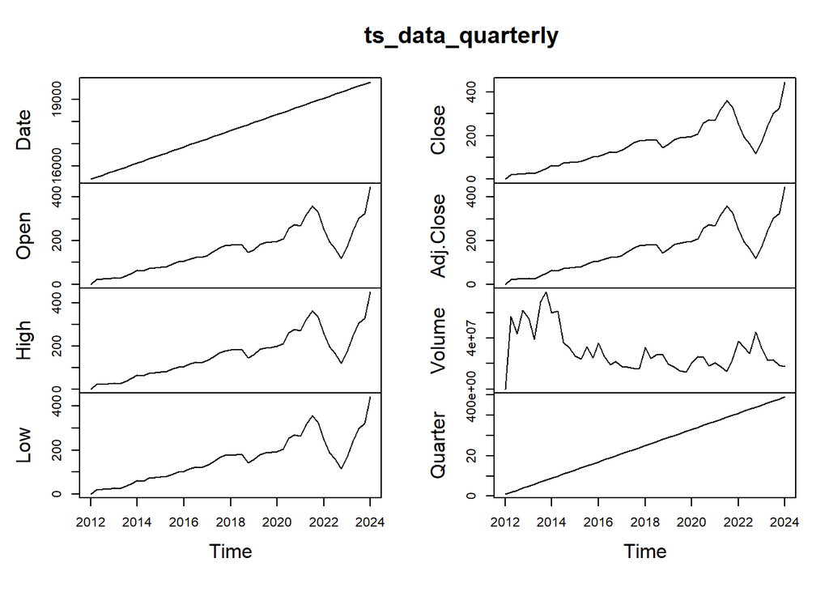

```r
plot(ts_data_quarterly)
```

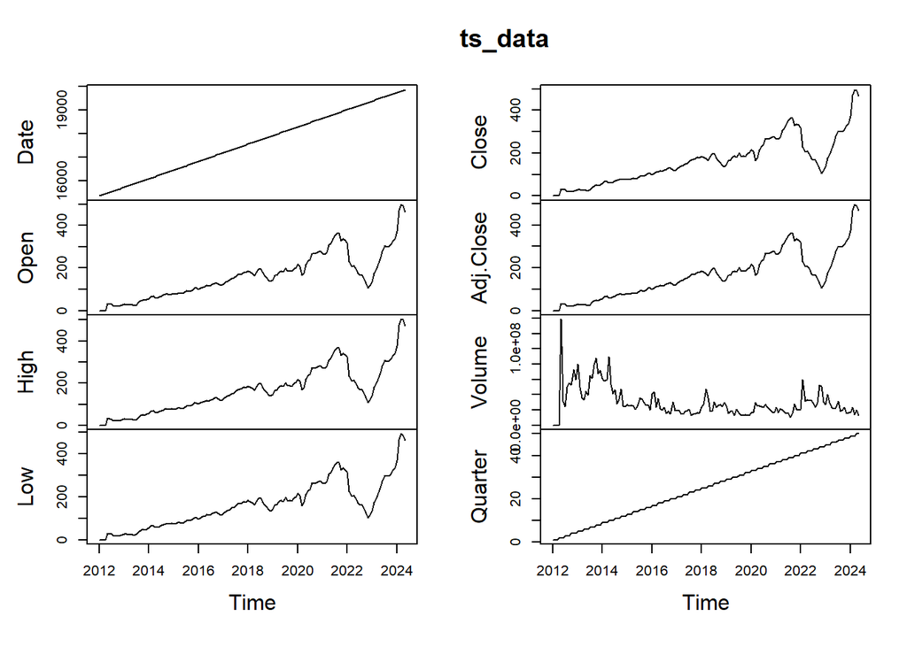

```r
plot(ts_data)
```

# Analýza

Časové řady jsou sekvence datových bodů měřených v čase. V našem případě jde o měsíční ceny akcií společnosti Meta. Při analýze časových řad nás zajímají tři hlavní složky:

- Trend: Dlouhodobý směr pohybu ceny, který může být rostoucí, klesající nebo stabilní.
- Sezónnost: Opakující se vzorce chování v pravidelných intervalech, často spojené s ročními obdobími nebo jinými cykly.
- Náhodná složka (rezidua): Náhodné fluktuace, které nelze vysvětlit trendem ani sezónností.

Při pohledu na trend jednotlivých analyzovaných složek jsme se rozhodli pro použití aditivního modelu.

# Dekompozice

Dekompozice časové řady je technika, která odděluje jednotlivé komponenty časové řady, což nám umožňuje lépe porozumět tomu, jak jednotlivé faktory přispívají k celkovému vývoji ceny akcií. V našem případě sledujeme, jaký podíl na změnách ceny má dlouhodobý trend a sezónní výkyvy.

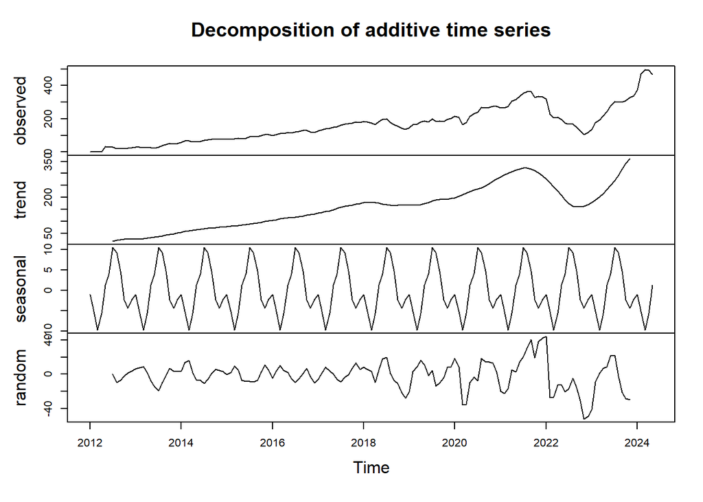

```r
# Dekompozice
decomposed <- decompose(ts_data)

decomp_close <- decompose(ts_data_close)
decomp_open <- decompose(ts_data_open)
decomp_vol <- decompose(ts_data_vol)

decomp_qclose <- decompose(ts_data_quarterly_close, type = "additive")
decomp_qopen <- decompose(ts_data_quarterly_open, type = "additive")
decomp_qvol <- decompose(ts_data_quarterly_vol, type = "additive")

# Vizualizace - dekompozice časové řady
# roční
plot(decomp_close)
```

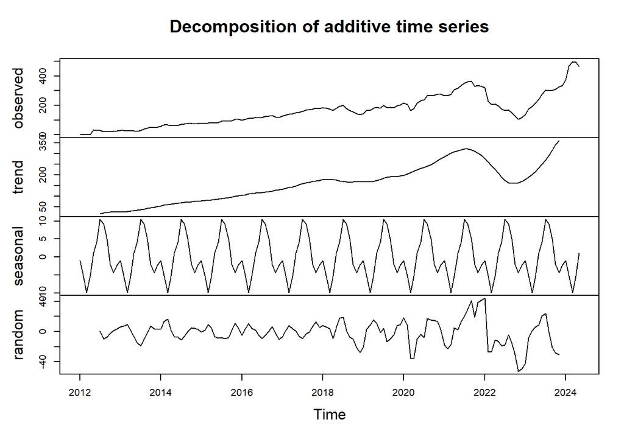

```r
plot(decomp_open)
```

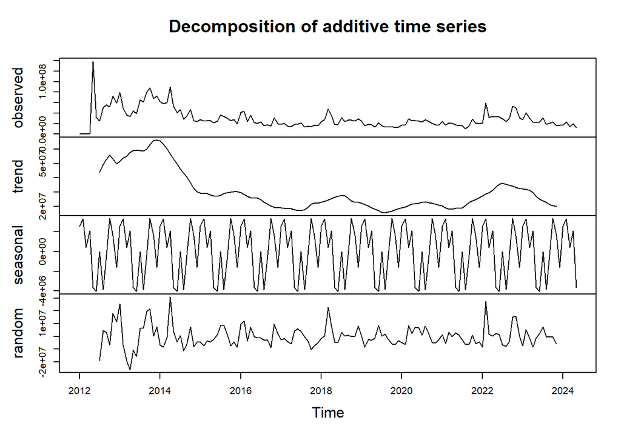

```r
plot(decomp_vol)
```

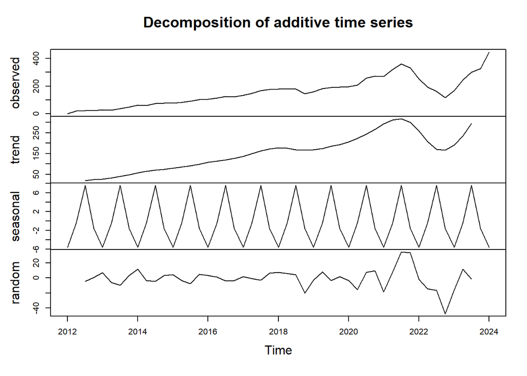

```r
# kvartální
plot(decomp_qclose)
```

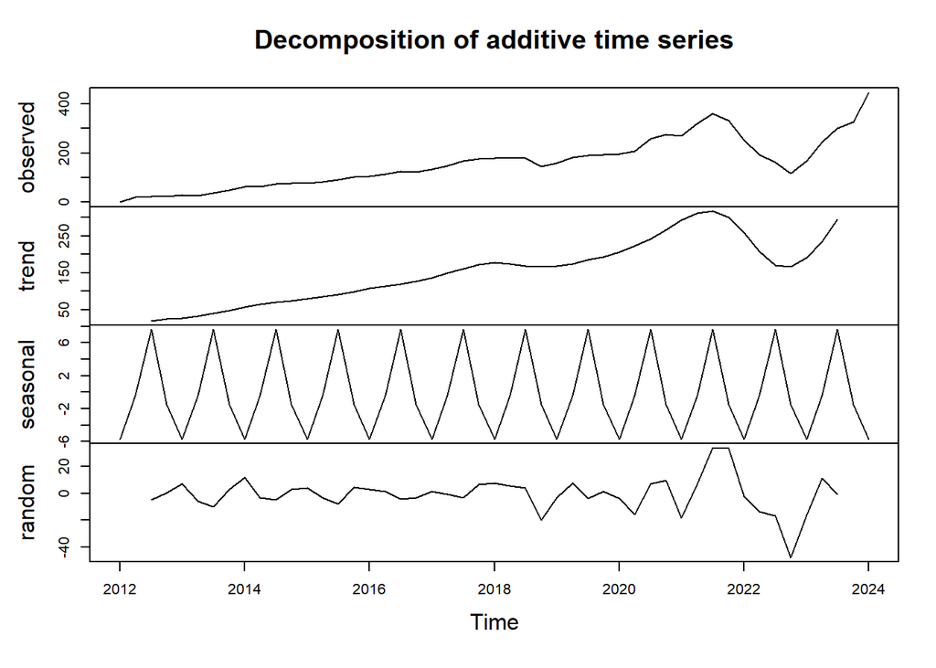

```r
plot(decomp_qopen)
```

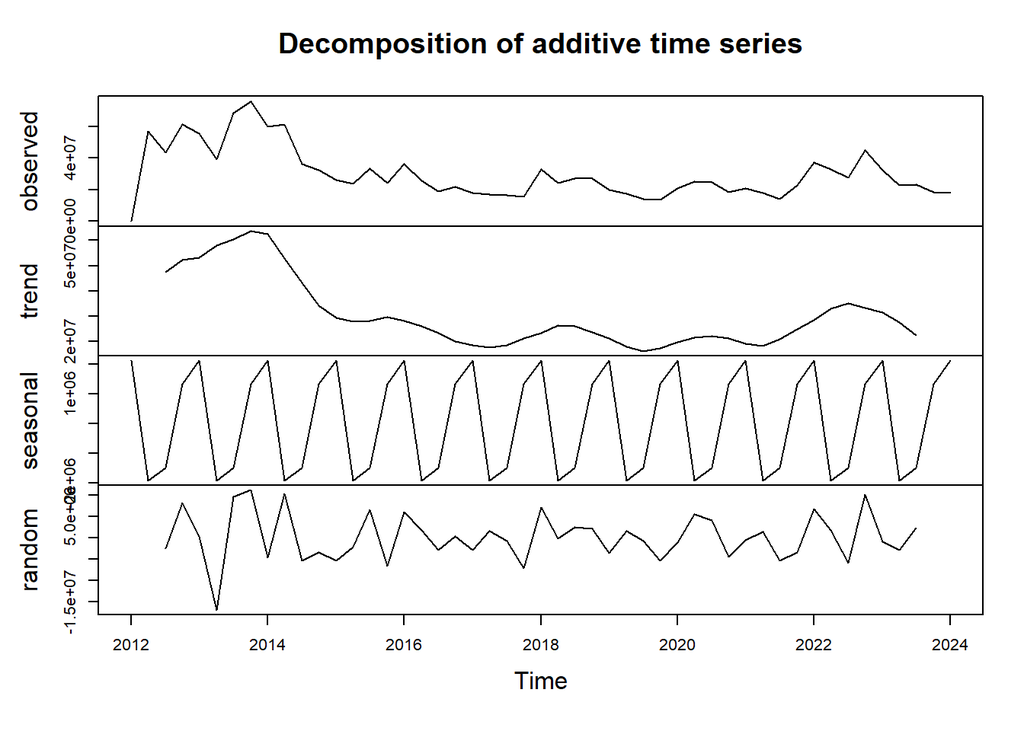

```r
plot(decomp_qvol)
```

# Vizualizace jednotlivých proměnných

Vytvoříme grafy pro jednotlivé proměnné Close, Volume a Open, které zobrazují původní data a jejich vyhlazení pomocí metody LOESS. LOESS (Locally Estimated Scatterplot Smoothing) je metoda pro vyhlazení časových řad a nalezení lokálních vzorců v datech. Je užitečná pro vizualizaci trendů a odstranění krátkodobých fluktuací.

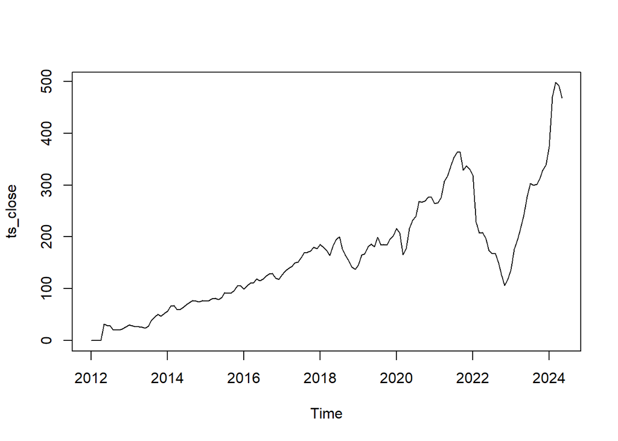

```r
# Budeme porovnávat - náhled do dat
# 1. vytvoříme Time Series pro dané proměnné
ts_close <- ts(data$Close, start = c(year(min(data$Date)), month(min(data$Date))), frequency = 12) # ročí - pro hodnotu Close
ts_volume <- ts(data$Volume, start = c(year(min(data$Date)), month(min(data$Date))), frequency = 12) # ročí - pro hodnotu Volume
ts_open <- ts(data$Open, start = c(year(min(data$Date)), month(min(data$Date))), frequency = 12) # ročí - pro hodnotu Volume

plot(ts_close)
```

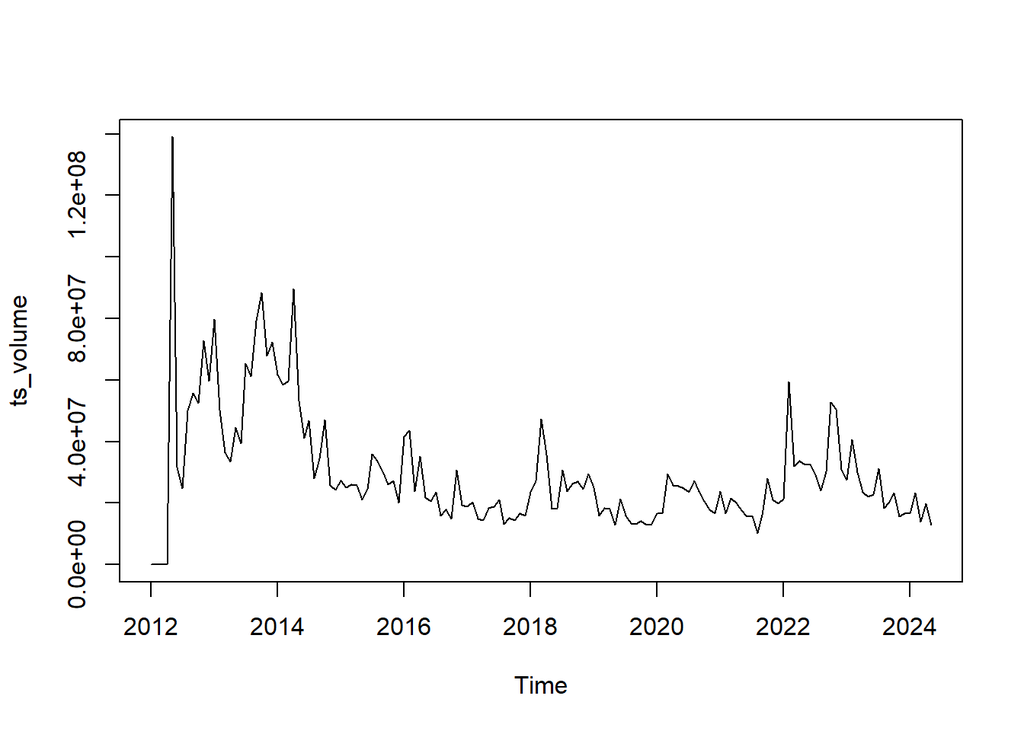

```r
plot(ts_volume)
```

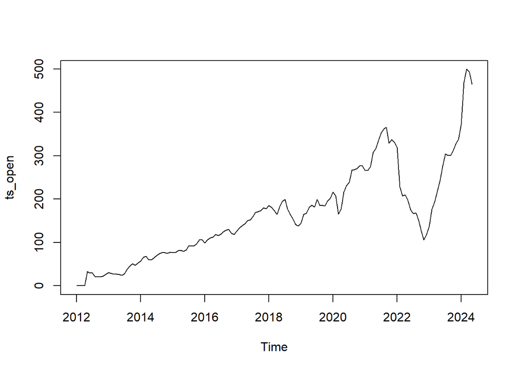

```r
plot(ts_open)
```

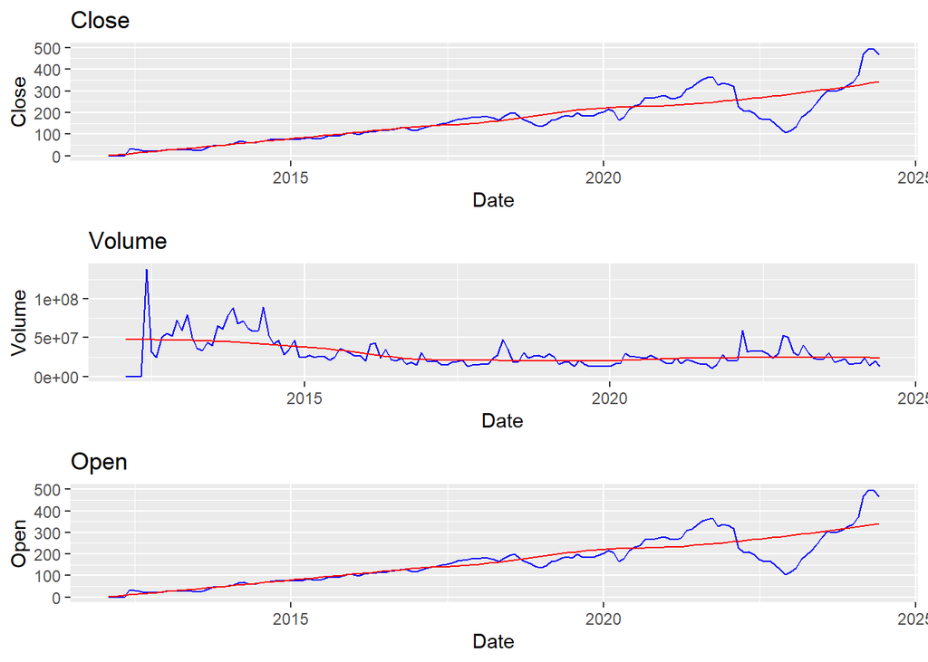

```r
# grafy jedotlivých proměnných s vyhlazením
p1 <- ggplot(data, aes(x = Date, y = Close)) +
  geom_line(color = "blue") +
  geom_smooth(method = "loess", color = "red", se = FALSE, size = 0.5) +
  ggtitle("Close")
p2 <- ggplot(data, aes(x = Date, y = Volume)) +
  geom_line(color = "blue") +
  geom_smooth(method = "loess", color = "red", se = FALSE, size = 0.5) +
  ggtitle("Volume")

p3 <- ggplot(data, aes(x = Date, y = Open)) +
  geom_line(color = "blue") +
  geom_smooth(method = "loess", color = "red", se = FALSE, size = 0.5) +
  ggtitle("Open")

# zobrazení
grid.arrange(p1, p2, p3, ncol = 1)
```

# Jednoduché exponenciální vyrovnání

Pro vyhlazení časových řad použijeme metodu jednoduchého exponenciálního vyrovnání (Simple Exponential Smoothing).

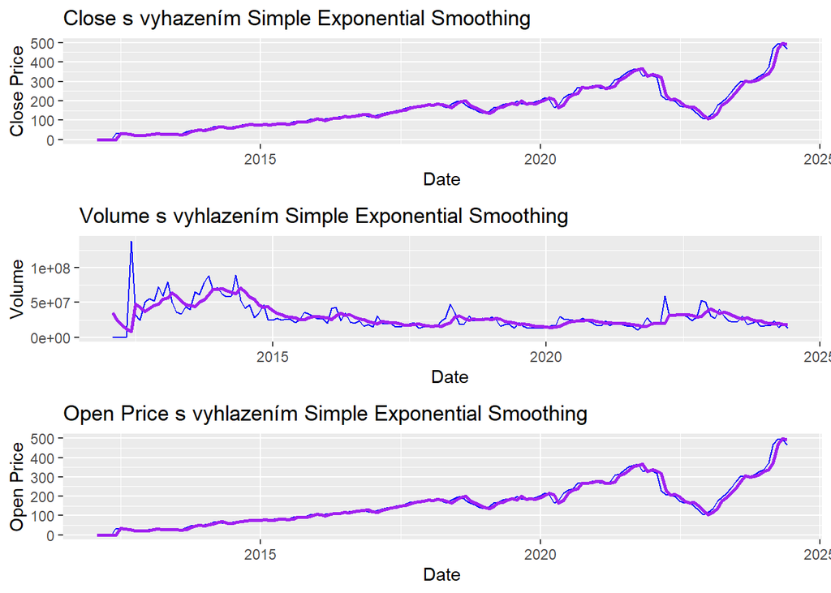

```r
# Jednoduché exponenciální vyrovnání
ses_close <- ses(data$Close, h = 12)
ses_open <- ses(data$Open, h = 12)
ses_volume <- ses(data$Volume, h = 12)

# Nahrání výsledků k půlvodnímu datasetu
data <- data %>%
  mutate(SES_Close = fitted(ses_close),
         SES_Open = fitted(ses_open),
         SES_Volume = fitted(ses_volume))

# Vizualizace
p4 <- ggplot(data, aes(x = Date)) +
  geom_line(aes(y = Close), color = "blue") +
  geom_line(aes(y = SES_Close), color = "purple", size = 1) +
  labs(title = "Close s vyhazením Simple Exponential Smoothing", x = "Date", y = "Close Price")

p5 <- ggplot(data, aes(x = Date)) +
  geom_line(aes(y = Volume), color = "blue") +
  geom_line(aes(y = SES_Volume), color = "purple", size = 1) +
  labs(title = "Volume s vyhlazením Simple Exponential Smoothing", x = "Date", y = "Volume")

p6 <- ggplot(data, aes(x = Date)) +
  geom_line(aes(y = Open), color = "blue") +
  geom_line(aes(y = SES_Open), color = "purple", size = 1) +
  labs(title = "Open Price s vyhlazením Simple Exponential Smoothing", x = "Date", y = "Open Price")

# Zobrazení grafů vedle sebe
grid.arrange(p4, p5, p6, ncol = 1)
```

# Autokorelační funkce

Následující část analyzuje autokorelační funkce reziduí po dekompozici časových řad. Autokorelační funkce (ACF) měří, jak jsou hodnoty časové řady v různých časech navzájem korelované. Pokud jsou hodnoty v řadě silně korelované, můžeme je použít pro předpověď budoucích hodnot. Vysoké hodnoty ACF na určitém zpoždění mohou indikovat sezónní cykly nebo přetrvávající trendy v datech.

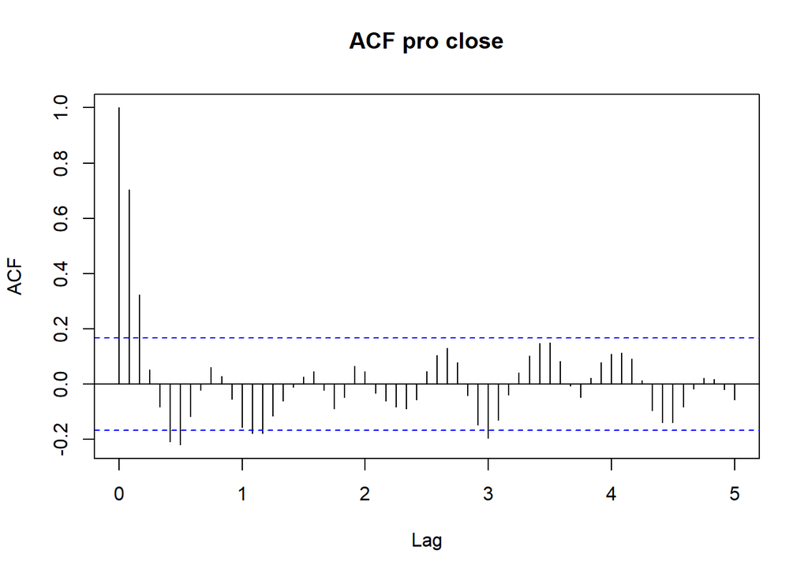

```r
# 3. Analýza

# Autokorelační funkce
lag_max <- 60 #-> 5 let
qlag_max <- 20 #-> 5 let
# ACF a PACF pro 'close'
residual_close <- decomp_close$random
residual_close <- na.omit(residual_close) # Odstranění NA hodnot
acf(residual_close, main="ACF pro close", lag.max=lag_max)
```

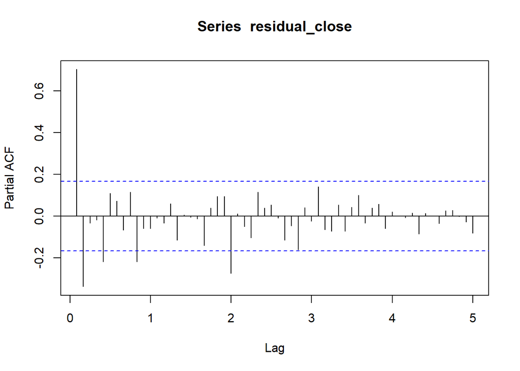

```r
#=> jsou prahové korelace - slabá korelace - v dlouhodobém posunu klesá
pacf(residual_close, lag.max=lag_max)
```

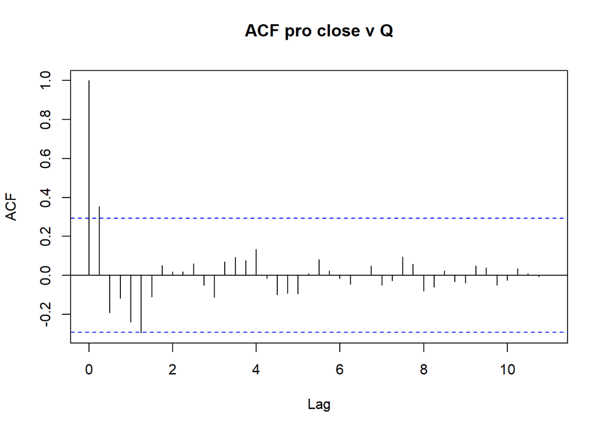

```r
#=> jsou prahové korelace - slabá korelace - v dlouhodobém posunu klesá

# kvartály
residual_qclose <- decomp_qclose$random
residual_qclose <- na.omit(residual_qclose) # Odstranění NA hodnot
acf(residual_qclose, main="ACF pro close v Q", lag.max=lag_max)
```

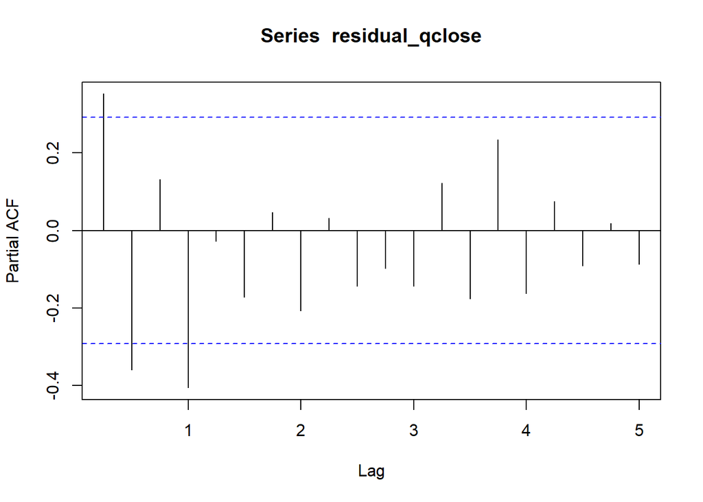

```r
#=> NEjsou prahové korelace - slabá korelace - v dlouhodobém posunu klesá
pacf(residual_qclose, lag.max=qlag_max)
```

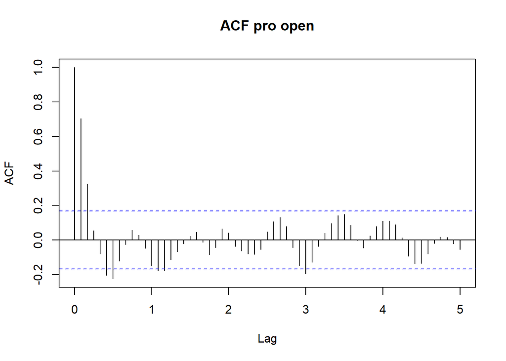

```r
#=> jsou prahové korelace - slabá korelace - v dlouhodobém posunu klesá

# ACF a PACF pro 'open'
residual_open <- decomp_open$random
residual_open <- na.omit(residual_open)
acf(residual_open, main="ACF pro open", lag.max=lag_max)
```

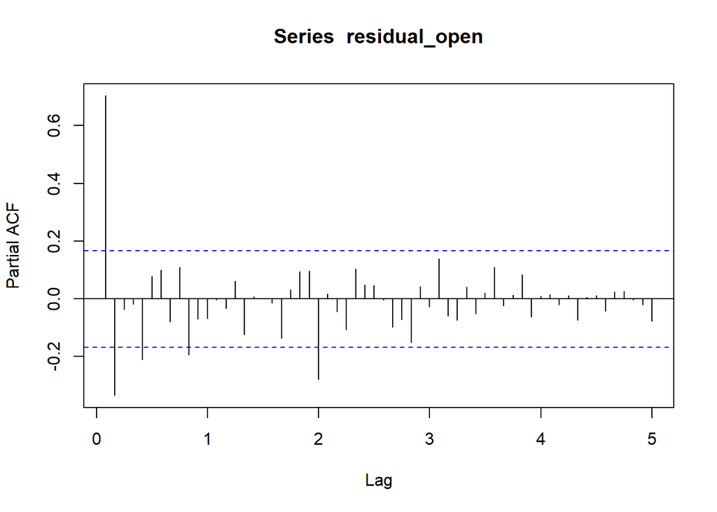

```r
#=> jsou prahové korelace - slabá korelace, ale vyskytuje se i ve 3. lagu
#- nějaký milník nebo pád
# - v dlouhodobém posunu klesá
pacf(residual_open, lag.max=lag_max)
```

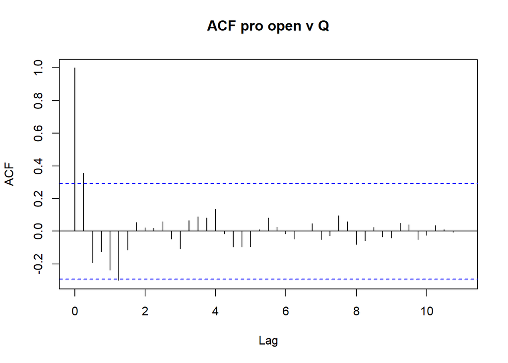

```r
#=> jsou prahové korelace - slabá korelace - v dlouhodobém posunu klesá

# kvartály
residual_qopen <- decomp_qopen$random
residual_qopen <- na.omit(residual_qopen)
acf(residual_qopen, main="ACF pro open v Q", lag.max=lag_max)
```

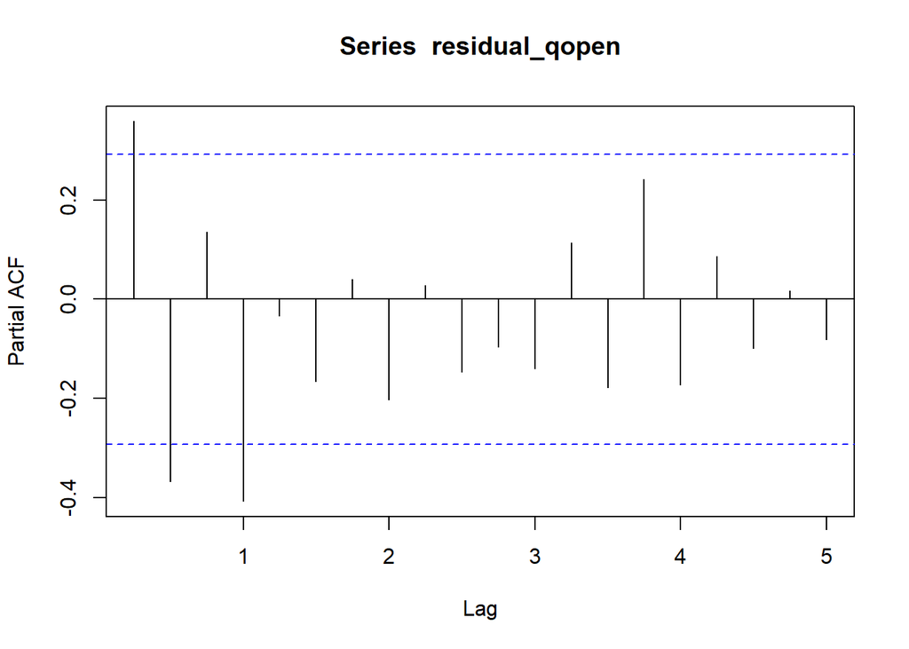

```r
#=> NEjsou prahové korelace - slabá korelace - v dlouhodobém posunu klesá
pacf(residual_qopen, lag.max=qlag_max)
```

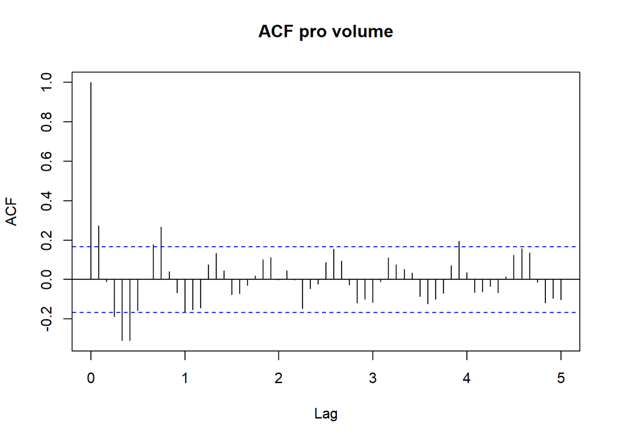

```r
#=> NEjsou prahové korelace - slabá korelace - v dlouhodobém posunu klesá

# ACF a PACF pro 'volume'
residual_volume <- decomp_vol$random
residual_volume <- na.omit(residual_volume)
acf(residual_volume, main="ACF pro volume", lag.max=lag_max)
```

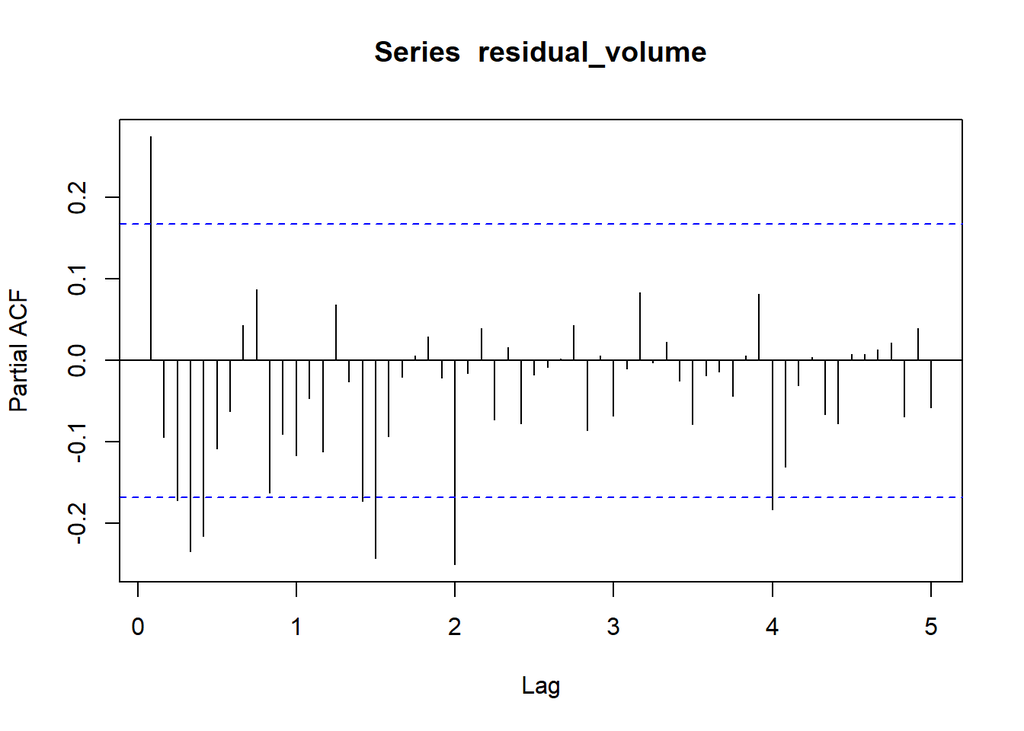

```r
#=> NEjsou prahové korelace - slabá korelace - v dlouhodobém posunu klesá
pacf(residual_volume, lag.max=lag_max)
```

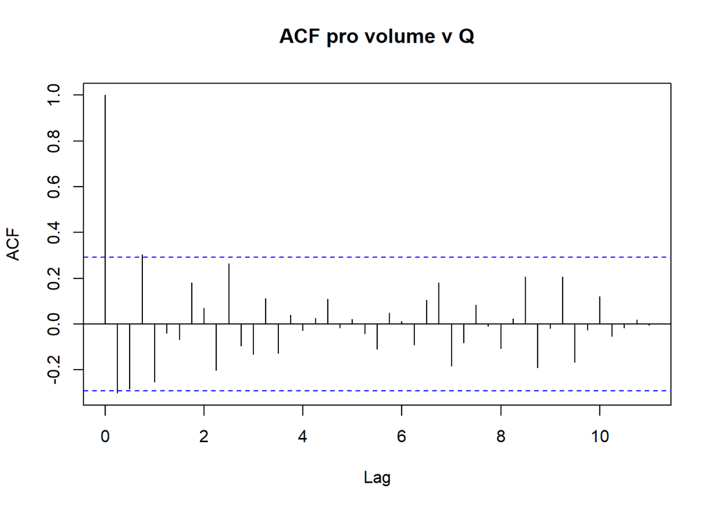

```r
#=> NEjsou prahové korelace - slabá korelace - v dlouhodobém posunu klesá

# kvartály
residual_qvol <- decomp_qvol$random
residual_qvol <- na.omit(residual_qvol)
acf(residual_qvol, main="ACF pro volume v Q", lag.max=lag_max)
```

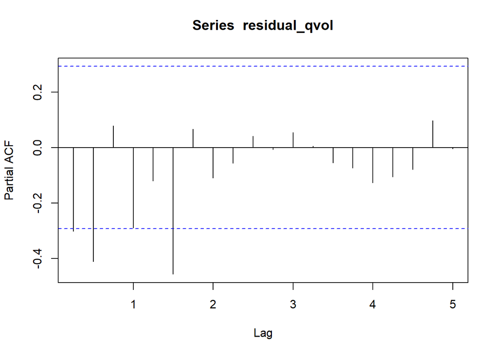

```r
#=> NEjsou prahové korelace - slabá korelace - v dlouhodobém posunu klesá
pacf(residual_qvol, lag.max=qlag_max)
```

```r
#=> jsou prahové korelace - 6. kvartál vůči 1. - slabá korelace - v dlouhodobém posunu klesá
```

# Modelování sezónnosti pomocí TSLM

Funkce tslm (Time Series Linear Model) v R slouží k vytváření lineárních modelů pro časové řady. V našem případě modelujeme jednotlivé časové řady (Close, Open, a Volume) jako funkce trendu a sezóny.

- Trend: Reprezentuje dlouhodobou změnu v časové řadě. Tento model se snaží zachytit, zda komponenta modelu dlouhodobě roste, klesá, nebo zůstává stabilní.
- Sezóna: Sezónní komponenta zachycuje pravidelně se opakující vzorce, které se vyskytují v časové řadě. Tyto vzorce mohou být způsobeny například ročními obdobími, měsíčními cykly nebo jinými pravidelnými faktory.

```r
# Vytvoření modelu sezónnosti pomocí tslm

# Model sezónnosti pro Close
model_close <- tslm(ts_close ~ trend + season)
summary(model_close)
```

```
##
## Call:
## tslm(formula = ts_close ~ trend + season)
##
## Residuals:
##      Min       1Q   Median       3Q      Max
## -172.183  -10.768   -0.868   11.476  179.435
##
## Coefficients:
##             Estimate Std. Error t value Pr(>|t|)
## (Intercept)  -2.1258    17.1534  -0.124    0.902
## trend         2.1703     0.1054  20.595   <2e-16 ***
## season2       3.4620    21.6826   0.160    0.873
## season3       1.3657    21.6834   0.063    0.950
## season4       4.0744    21.6847   0.188    0.851
## season5      10.2417    21.6865   0.472    0.637
## season6       1.2426    22.1297   0.056    0.955
## season7       7.0464    22.1295   0.318    0.751
## season8       6.5594    22.1297   0.296    0.767
## season9       3.1796    22.1305   0.144    0.886
## season10     -2.5164    22.1317  -0.114    0.910
## season11     -3.6063    22.1335  -0.163    0.871
## season12     -3.6899    22.1357  -0.167    0.868
## ---
## Signif. codes:  0 '***' 0.001 '**' 0.01 '*' 0.05 '.' 0.1 ' ' 1
##
## Residual standard error: 55.28 on 136 degrees of freedom
## Multiple R-squared:  0.7577, Adjusted R-squared:  0.7364
## F-statistic: 35.45 on 12 and 136 DF,  p-value: < 2.2e-16
```

```r
model_close$coefficients
```

```
## (Intercept)       trend     season2     season3     season4     season5
##   -2.125818    2.170311    3.462047    1.365710    4.074446   10.241743
##     season6     season7     season8     season9    season10    season11
##    1.242613    7.046396    6.559400    3.179627   -2.516416   -3.606288
##    season12
##   -3.689947
```

```r
# Model sezónnosti pro Open
model_open <- tslm(ts_open ~ trend + season)
summary(model_open)
```

```
##
## Call:
## tslm(formula = ts_open ~ trend + season)
##
## Residuals:
##     Min      1Q  Median      3Q     Max
## -172.74  -11.04   -0.90   11.22  181.25
##
## Coefficients:
##             Estimate Std. Error t value Pr(>|t|)
## (Intercept)  -2.1410    17.1671  -0.125    0.901
## trend         2.1676     0.1055  20.553   <2e-16 ***
## season2       3.4982    21.6999   0.161    0.872
## season3       1.4726    21.7007   0.068    0.946
## season4       4.5683    21.7020   0.210    0.834
## season5      10.0114    21.7038   0.461    0.645
## season6       1.3662    22.1474   0.062    0.951
## season7       7.0795    22.1471   0.320    0.750
## season8       6.6093    22.1474   0.298    0.766
## season9       3.6361    22.1481   0.164    0.870
## season10     -2.1404    22.1494  -0.097    0.923
## season11     -3.4706    22.1512  -0.157    0.876
## season12     -3.5892    22.1534  -0.162    0.872
## ---
## Signif. codes:  0 '***' 0.001 '**' 0.01 '*' 0.05 '.' 0.1 ' ' 1
##
## Residual standard error: 55.32 on 136 degrees of freedom
## Multiple R-squared:  0.757,  Adjusted R-squared:  0.7355
## F-statistic:  35.3 on 12 and 136 DF,  p-value: < 2.2e-16
```

```r
model_open$coefficients
```

```
## (Intercept)       trend     season2     season3     season4     season5
##   -2.141035    2.167614    3.498224    1.472622    4.568255   10.011442
##     season6     season7     season8     season9    season10    season11
##    1.366245    7.079549    6.609271    3.636139   -2.140440   -3.470605
##    season12
##   -3.589164
```

```r
# Model sezónnosti pro Volume
model_volume <- tslm(ts_volume ~ trend + season)
summary(model_volume)
```

```
##
## Call:
## tslm(formula = ts_volume ~ trend + season)
##
## Residuals:
##       Min        1Q    Median        3Q       Max
## -43859139  -9915179  -2201673   7369649  91925354
##
## Coefficients:
##             Estimate Std. Error t value Pr(>|t|)
## (Intercept) 42980688    5641387   7.619 3.91e-12 ***
## trend        -184302      34657  -5.318 4.20e-07 ***
## season2      1247055    7130953   0.175    0.861
## season3     -1943278    7131206  -0.273    0.786
## season4       -77294    7131627  -0.011    0.991
## season5      5072491    7132217   0.711    0.478
## season6     -3707475    7277995  -0.509    0.611
## season7       818789    7277913   0.113    0.911
## season8     -2714743    7277995  -0.373    0.710
## season9      1062120    7278243   0.146    0.884
## season10     5123682    7278656   0.704    0.483
## season11     3207107    7279233   0.441    0.660
## season12     -417903    7279976  -0.057    0.954
## ---
## Signif. codes:  0 '***' 0.001 '**' 0.01 '*' 0.05 '.' 0.1 ' ' 1
##
## Residual standard error: 18180000 on 136 degrees of freedom
## Multiple R-squared:  0.1861, Adjusted R-squared:  0.1143
## F-statistic: 2.591 on 12 and 136 DF,  p-value: 0.003928
```

```r
model_volume$coefficients
```

```
## (Intercept)       trend     season2     season3     season4     season5
## 42980687.50  -184302.05  1247055.33 -1943277.96   -77294.37  5072490.58
##     season6     season7     season8     season9    season10    season11
## -3707474.73   818789.40 -2714742.63  1062120.10  5123682.03  3207107.15
##    season12
##  -417903.32
```

```r
model_qclose <- tslm(ts_data_quarterly_close ~ trend + season)
summary(model_qclose)
```

```
##
## Call:
## tslm(formula = ts_data_quarterly_close ~ trend + season)
##
## Residuals:
##      Min       1Q   Median       3Q      Max
## -156.622   -9.907   -1.772   12.226  137.417
##
## Coefficients:
##             Estimate Std. Error t value Pr(>|t|)
## (Intercept)   4.0721    18.9392   0.215    0.831
## trend         6.2406     0.5104  12.227 9.54e-16 ***
## season2      -5.1646    20.2080  -0.256    0.799
## season3       3.9859    20.2015   0.197    0.844
## season4      -4.6098    20.2080  -0.228    0.821
## ---
## Signif. codes:  0 '***' 0.001 '**' 0.01 '*' 0.05 '.' 0.1 ' ' 1
##
## Residual standard error: 50.46 on 44 degrees of freedom
## Multiple R-squared:  0.7734, Adjusted R-squared:  0.7528
## F-statistic: 37.54 on 4 and 44 DF,  p-value: 1.18e-13
```

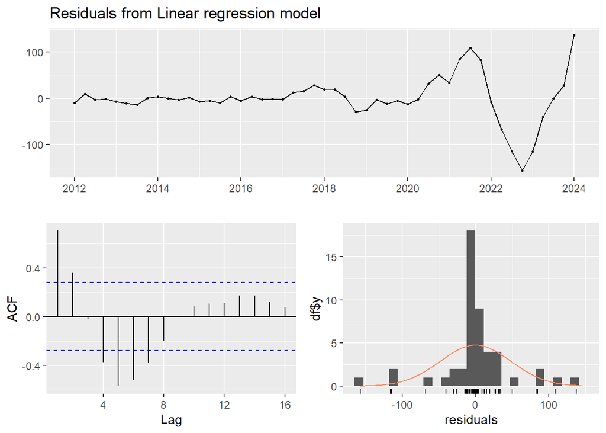

```
##
##  Breusch-Godfrey test for serial correlation of order up to 8
##
## data:  Residuals from Linear regression model
## LM test = 44.589, df = 8, p-value = 4.403e-07
```

```r
checkresiduals(model_qclose)
```

Y_t = − 2.126 + 2.170 * trend + 3.462 * season2 + 1.366 * season3 + 4.074 * season4 + 10.242 * season5 + 1.243*season6 + 7.046* season7 + 6.559 * season8 + 3.180 * season9 −2.516 * season10 − 3.606 * season11 − 3.690 * season12

Největší vliv má sezoní složka 5. měsíce - 10.242* na jednotku druhý: s koeficientem 7.046* na jednotku - 7. měsíc třetí: 6.559*season8 - 8. měsíc podle p-value není ani jedna sezona význmaná

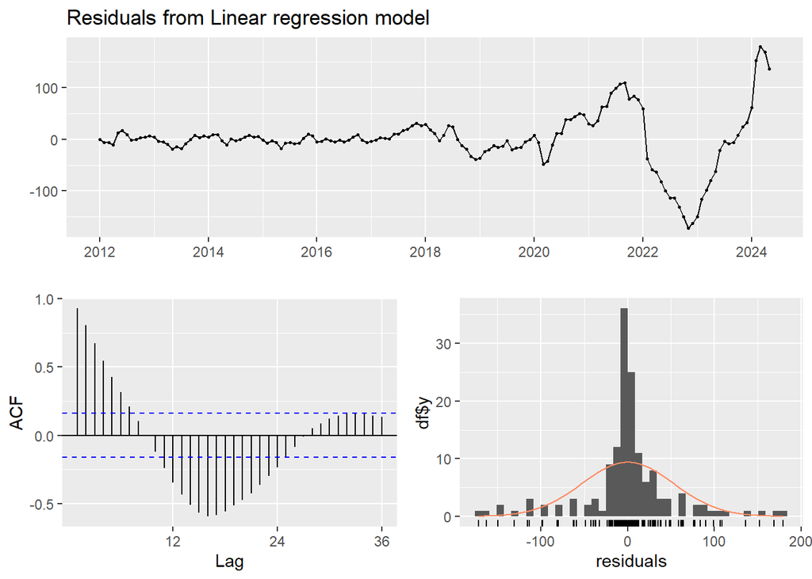

```
##
##  Breusch-Godfrey test for serial correlation of order up to 24
##
## data:  Residuals from Linear regression model
## LM test = 142.11, df = 24, p-value < 2.2e-16
```

```r
checkresiduals(model_close)
```

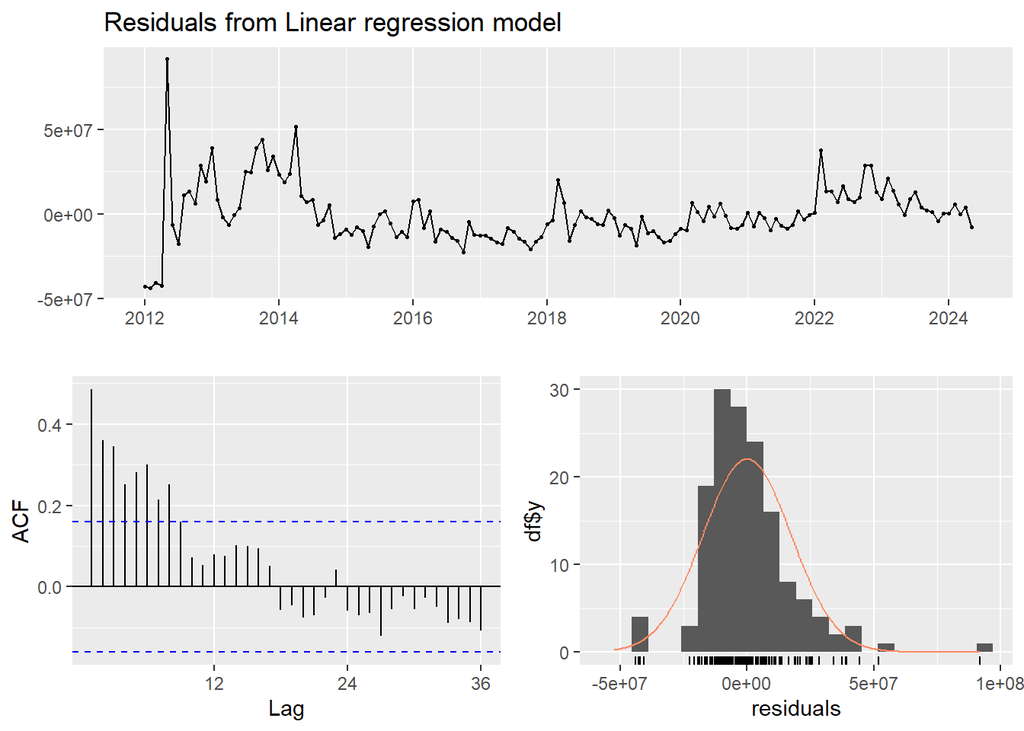

```
##
##  Breusch-Godfrey test for serial correlation of order up to 24
##
## data:  Residuals from Linear regression model
## LM test = 53.676, df = 24, p-value = 0.0004708
```

```r
checkresiduals(model_volume)
```

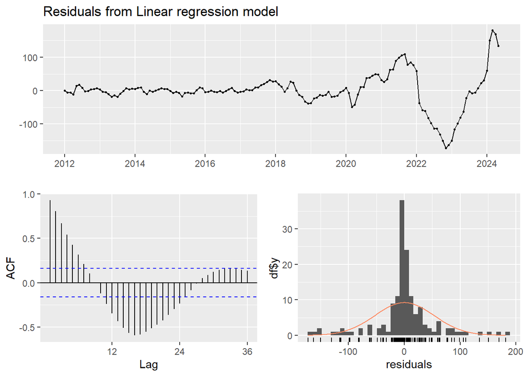

```
##
##  Breusch-Godfrey test for serial correlation of order up to 24
##
## data:  Residuals from Linear regression model
## LM test = 142.07, df = 24, p-value < 2.2e-16
```

```r
checkresiduals(model_open)
```

Pro všechny modely platila pro první dva roky významná korelace - střední, residua mají přibližně normálí rozdělení.

# Předpověď pomocí modelu sezónnosti

Po vytvoření modelů použijeme funkci forecast, která nám umožní předpovědět budoucí hodnoty na základě modelu sezónnosti.

Předpověď časové řady na základě modelu sezónnosti nám umožňuje odhadnout budoucí vývoj. Funkce forecast generuje předpovědi pro budoucí období na základě trendu a sezónní složky identifikované v modelu.

Horizont předpovědi (h = 12): Určuje, kolik časových období chceme předpovědět. V našem případě je to 12 měsíců. Intervalu spolehlivosti: Funkce forecast také vypočítává interval spolehlivosti, což je rozsah hodnot, ve kterém by se s určitou pravděpodobností měly nacházet skutečné budoucí hodnoty.

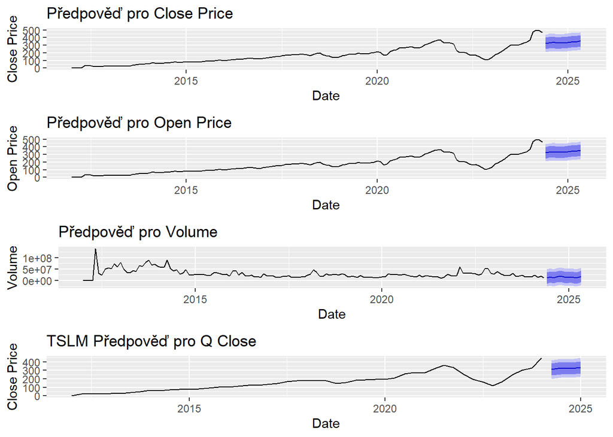

```r
# Předpověď pomocí modelu sezónnosti
fc_close <- forecast(model_close, h = 12)
fc_open <- forecast(model_open, h = 12)
fc_volume <- forecast(model_volume, h = 12)
fc_qclose <- forecast(model_qclose, h=4)

# Vizualizace výsledků modelu a předpovědi
p7 <- autoplot(fc_close) +
  labs(title = "Předpověď pro Close Price", x = "Date", y = "Close Price")

p8 <- autoplot(fc_open) +
  labs(title = "Předpověď pro Open Price", x = "Date", y = "Open Price")

p9 <- autoplot(fc_volume) +
  labs(title = "Předpověď pro Volume", x = "Date", y = "Volume")

p10 <- autoplot(fc_qclose)+
    labs(title = "TSLM Předpověď pro Q Close", x = "Date", y = "Close Price")


# Zobrazení grafů vedle sebe
grid.arrange(p7, p8, p9, p10, ncol = 1)
```

# Modely SARIMA a ETS

V této části se zaměříme na pokročilejší modely pro analýzu časových řad jako jsou SARIMA a ETS.

# SARIMA

SARIMA je rozšíření modelu ARIMA o sezónní komponenty.

```r
# Roční close
sarima_close <- auto.arima(ts_close, seasonal=TRUE)
fitted_values_close <- fitted(sarima_close)

summary(sarima_close)
```

```
## Series: ts_close
## ARIMA(2,1,2) with drift
##
## Coefficients:
##           ar1      ar2     ma1     ma2   drift
##       -0.7714  -0.3412  1.2630  0.8247  3.2478
## s.e.   0.1190   0.1126  0.0781  0.0752  1.7310
##
## sigma^2 = 215.5:  log likelihood = -605.67
## AIC=1223.34   AICc=1223.94   BIC=1241.32
##
## Training set error measures:
##                       ME     RMSE      MAE  MPE MAPE      MASE      ACF1
## Training set -0.03733222 14.38276 9.287786 -Inf  Inf 0.1479537 0.0261126
```

```r
# Optimali ARIMA model: ARIMA(2,1,2)
# => AR - využíváme 2 předchozí hodnoty časové řady k predikci současné hodnoty
# => I - Diference: data byly jednou diferencovaná  kvůli stacionaritě
# => MA - zohledňuje dvě předchozí chyby (rezidua) k predikci současné hodnoty
# => Drift - trend v modelu - konstanta

# ar - autoregresní koefeicienty
# ma - koeficienty klouzavého průměru


predict_sarima_close <- forecast(fitted_values_close, h=12)

ps1 <- autoplot(ts_close, series="Vstupní data")+
  autolayer(predict_sarima_close , series="Predikce SARIMA - close")+
  labs(title = "SARIMA - Předpověď pro Close", x = "Date", y = "Close")


# Roční open
sarima_open <- auto.arima(ts_open, seasonal=TRUE)
fitted_values_open <- fitted(sarima_open)

summary(sarima_open)
```

```
## Series: ts_open
## ARIMA(3,1,3) with drift
##
## Coefficients:
##           ar1      ar2      ar3     ma1     ma2     ma3   drift
##       -1.7131  -1.0440  -0.2330  2.2532  2.0878  0.8008  3.1779
## s.e.   0.1194   0.1962   0.1108  0.0804  0.1383  0.0735  1.7962
##
## sigma^2 = 212.4:  log likelihood = -603.77
## AIC=1223.54   AICc=1224.58   BIC=1247.52
##
## Training set error measures:
##                       ME     RMSE     MAE  MPE MAPE      MASE       ACF1
## Training set -0.02646034 14.17624 9.22358 -Inf  Inf 0.1470016 0.01141488
```

```r
# ARIMA(3,1,3) with drift
predict_sarima_open <- forecast(fitted_values_open, h=12)

ps2 <- autoplot(ts_open, series="Vstupní data")+
  autolayer(predict_sarima_open , series="Predikce SARIMA - open")+
  labs(title = "SARIMA - Předpověď pro Open", x = "Date", y = "Open")


# Roční volume
sarima_volume <- auto.arima(ts_volume, seasonal=TRUE)
fitted_values_volume <- fitted(sarima_volume)
summary(sarima_volume)
```

```
## Series: ts_volume
## ARIMA(0,1,1)
##
## Coefficients:
##           ma1
##       -0.6553
## s.e.   0.0701
##
## sigma^2 = 2.32e+14:  log likelihood = -2657.55
## AIC=5319.1   AICc=5319.18   BIC=5325.1
##
## Training set error measures:
##                    ME     RMSE     MAE       MPE     MAPE      MASE       ACF1
## Training set 282315.7 15130521 8012902 -8.720252 25.21381 0.5173599 0.04362042
```

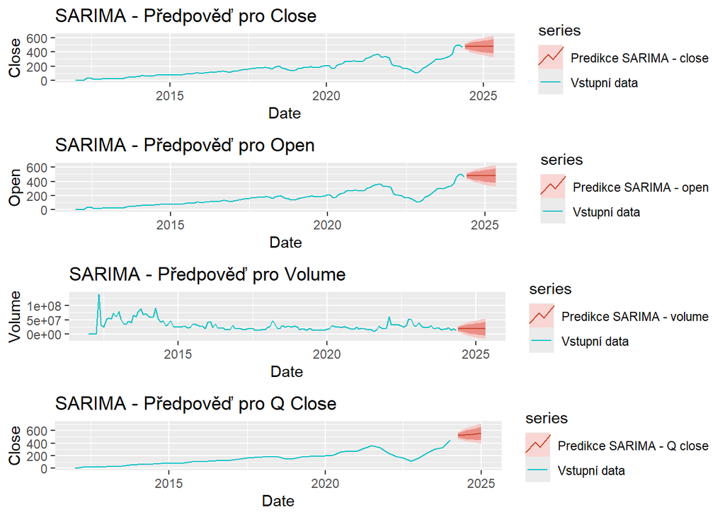

```r
# ARIMA(0,1,1)

predict_sarima_volume <- forecast(fitted_values_volume, h=12)

ps3 <- autoplot(ts_volume, series="Vstupní data")+
  autolayer(predict_sarima_volume , series="Predikce SARIMA - volume")+
  labs(title = "SARIMA - Předpověď pro Volume", x = "Date", y = "Volume")


# SARIMA kvartál close
sarima_qclose <- auto.arima(ts_data_quarterly_close, seasonal=TRUE)

# Vypočítané hodnoty modelem
fitted_values_qclose <- fitted(sarima_qclose)
pred_q_sarima_close <- forecast(sarima_qclose, h=4)

# Vizualizace
ps4 <- autoplot(ts_data_quarterly_close, series="Vstupní data")+
  autolayer(pred_q_sarima_close, series="Predikce SARIMA - Q close")+
  labs(title = "SARIMA - Předpověď pro Q Close", x = "Date", y = "Close")

grid.arrange(ps1, ps2, ps3, ps4, ncol = 1)
```

# ETS

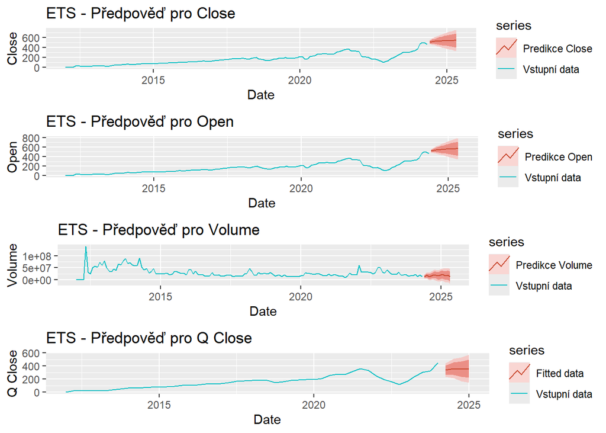

```r
# Roční Close
ets_model_close <- ets(ts_close)
ets_fitted_close <- fitted(ets_model_close)
ets_pred_close <- forecast(ets_fitted_close,h=12)

pe1 <- autoplot(ts_close, series="Vstupní data") +
  autolayer(ets_pred_close  , series="Predikce Close")+
  labs(title = "ETS - Předpověď pro Close", x = "Date", y = "Close")

# Roční Open
ets_model_open <- ets(ts_open, model="AAA")
ets_fitted_open <- fitted(ets_model_open)
ets_pred_open <- forecast(ets_fitted_open,h=12)

pe2 <- autoplot(ts_open, series="Vstupní data") +
  autolayer(ets_pred_open  , series="Predikce Open") +
  labs(title = "ETS - Předpověď pro Open", x = "Date", y = "Open")


# Roční Volume
ets_model_volume <- ets(ts_volume, model="AAA")
ets_fitted_volume <- fitted(ets_model_volume)
ets_pred_volume <- forecast(ets_fitted_volume,h=12)

pe3 <- autoplot(ts_volume, series="Vstupní data") +
  autolayer(ets_pred_volume  , series="Predikce Volume") +
  labs(title = "ETS - Předpověď pro Volume", x = "Date", y = "Volume")


# Close Q

ets_model_qclose <- ets(ts_data_quarterly_close, model="AAA") # změna na automatickou volbu modelu
ets_fitted_qclose <-fitted(ets_model_qclose)
ets_pred_qclose <- forecast(ets_fitted_qclose, h=4)

# ETS - vizualizace
pe4 <- autoplot(ts_data_quarterly_close, series="Vstupní data") +
  autolayer(ets_pred_qclose , series="Fitted data") +
  labs(title = "ETS - Předpověď pro Q Close", x = "Date", y = "Q Close")

grid.arrange(pe1, pe2, pe3, pe4, ncol = 1)
```

# SMA vyhlazení

Klouzavý průměr (SMA) je účinný nástroj pro vyhlazení časových řad. SMA průměruje předchozí hodnoty a vytváří tak vyrovnaný trend.

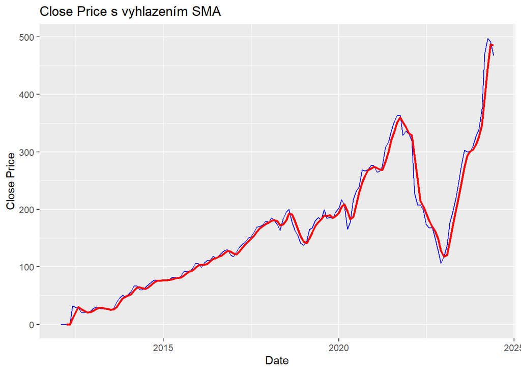

```r
# SMA pro Close
sma_close <- SMA(data$Close, n = 3) # 3-měsíční klouzavý průměr

# Vizualizace SMA modelu
ggplot(data, aes(x = Date)) +
  geom_line(aes(y = Close), color = "blue") +
  geom_line(aes(y = sma_close), color = "red", size = 1) +
  labs(title = "Close Price s vyhlazením SMA", x = "Date", y = "Close Price")
```

# Kroskorelační Funkce

Analyzujeme kroskorelace mezi různými proměnnými časových řad. Z této funkce získáme srovnání jak spolu ostatní řady souvidí a jak se navzájem ovlivňují.

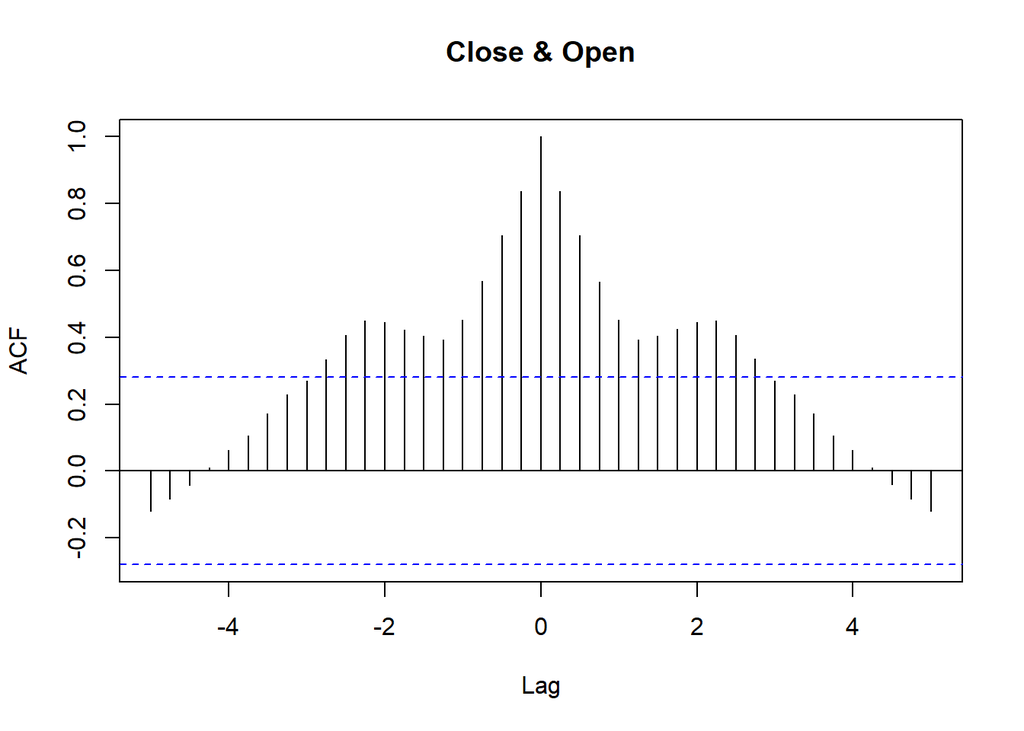

```r
Close = ts_data_quarterly[,'Close']
Open = ts_data_quarterly[, 'Open']
High = ts_data_quarterly[, 'High']
Low = ts_data_quarterly[, 'Low']
Volume = ts_data_quarterly[, 'Volume']

lag <- 20 #-> 5 let
ccf(Close, Open,na.action =na.pass, lag=lag)
```

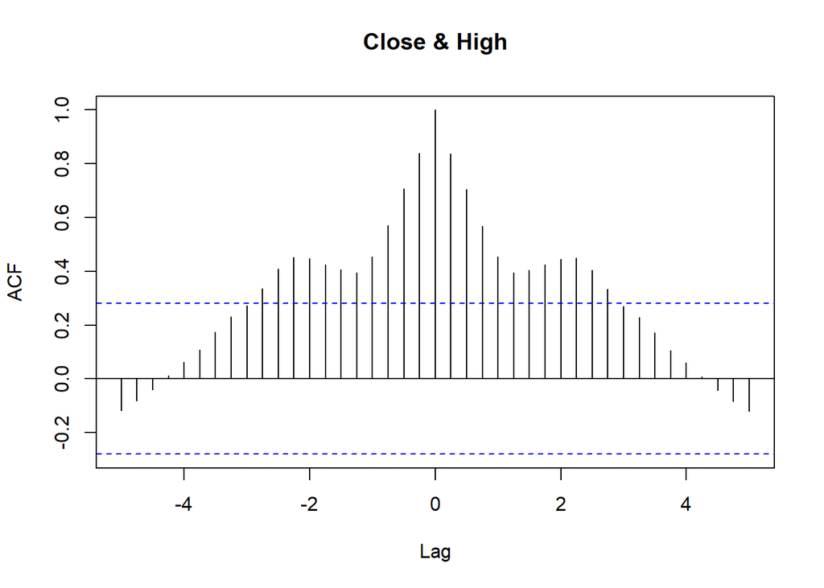

```r
ccf(Close, High,na.action =na.pass, lag=lag)
```

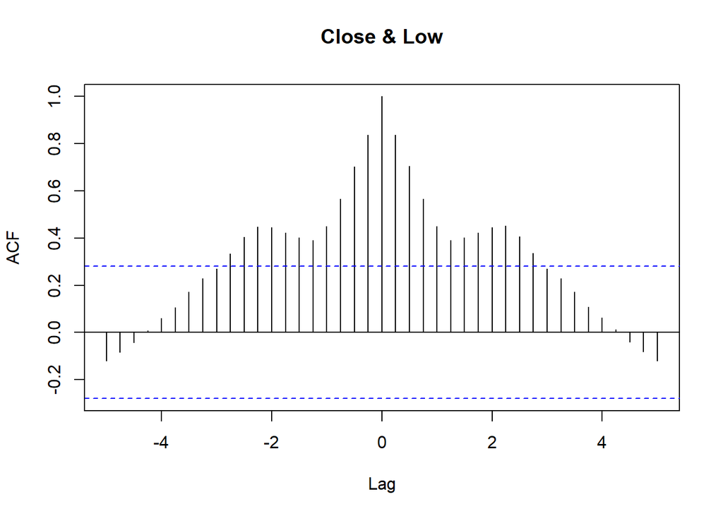

```r
ccf(Close, Low,na.action =na.pass, lag=lag)
```

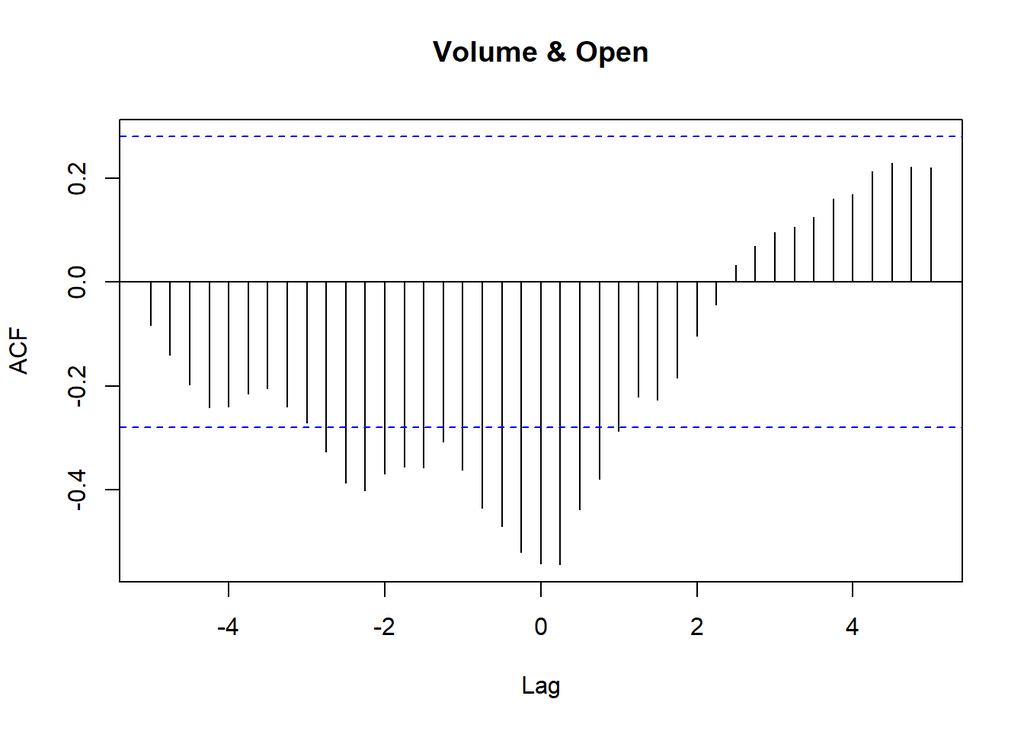

```r
ccf(Volume, Open,na.action =na.pass, lag=lag)
```